# Risk Factor Analysis

## Outcome Variable

**Outcome Variable:** pers_wasted624

## Predictor Variables

**Intervention Variable:** ever_sunderweight06

**Adjustment Set:**

unadjusted

## Stratifying Variables

The analysis was stratified on these variable(s):

- studyid
- country

## Data Summary

| studyid | country | ever_sunderweight06 | pers_wasted624 | n_cell | n |
| --- | --- | --- | --- | --- | --- |
| CMC-V-BCS-2002 | INDIA | 0 | 0 | 285 | 373 |
| CMC-V-BCS-2002 | INDIA | 0 | 1 | 12 | 373 |
| CMC-V-BCS-2002 | INDIA | 1 | 0 | 60 | 373 |
| CMC-V-BCS-2002 | INDIA | 1 | 1 | 16 | 373 |
| CMIN | BANGLADESH | 0 | 0 | 194 | 252 |
| CMIN | BANGLADESH | 0 | 1 | 11 | 252 |
| CMIN | BANGLADESH | 1 | 0 | 33 | 252 |
| CMIN | BANGLADESH | 1 | 1 | 14 | 252 |
| COHORTS | GUATEMALA | 0 | 0 | 904 | 1023 |
| COHORTS | GUATEMALA | 0 | 1 | 20 | 1023 |
| COHORTS | GUATEMALA | 1 | 0 | 78 | 1023 |
| COHORTS | GUATEMALA | 1 | 1 | 21 | 1023 |
| COHORTS | INDIA | 0 | 0 | 5698 | 6897 |
| COHORTS | INDIA | 0 | 1 | 423 | 6897 |
| COHORTS | INDIA | 1 | 0 | 428 | 6897 |
| COHORTS | INDIA | 1 | 1 | 348 | 6897 |
| COHORTS | PHILIPPINES | 0 | 0 | 2460 | 2809 |
| COHORTS | PHILIPPINES | 0 | 1 | 154 | 2809 |
| COHORTS | PHILIPPINES | 1 | 0 | 123 | 2809 |
| COHORTS | PHILIPPINES | 1 | 1 | 72 | 2809 |
| CONTENT | PERU | 0 | 0 | 213 | 215 |
| CONTENT | PERU | 0 | 1 | 0 | 215 |
| CONTENT | PERU | 1 | 0 | 2 | 215 |
| CONTENT | PERU | 1 | 1 | 0 | 215 |
| EE | PAKISTAN | 0 | 0 | 207 | 374 |
| EE | PAKISTAN | 0 | 1 | 9 | 374 |
| EE | PAKISTAN | 1 | 0 | 118 | 374 |
| EE | PAKISTAN | 1 | 1 | 40 | 374 |
| GMS-Nepal | NEPAL | 0 | 0 | 437 | 590 |
| GMS-Nepal | NEPAL | 0 | 1 | 70 | 590 |

[output cut: 90 more lines]

The following strata were considered:

- studyid: CMC-V-BCS-2002, country: INDIA
- studyid: CMIN, country: BANGLADESH
- studyid: COHORTS, country: GUATEMALA
- studyid: COHORTS, country: INDIA
- studyid: COHORTS, country: PHILIPPINES
- studyid: CONTENT, country: PERU
- studyid: EE, country: PAKISTAN
- studyid: GMS-Nepal, country: NEPAL
- studyid: Guatemala BSC, country: GUATEMALA
- studyid: IRC, country: INDIA
- studyid: JiVitA-3, country: BANGLADESH
- studyid: JiVitA-4, country: BANGLADESH
- studyid: Keneba, country: GAMBIA
- studyid: LCNI-5, country: MALAWI
- studyid: MAL-ED, country: BANGLADESH
- studyid: MAL-ED, country: BRAZIL
- studyid: MAL-ED, country: INDIA
- studyid: MAL-ED, country: NEPAL
- studyid: MAL-ED, country: PERU
- studyid: MAL-ED, country: SOUTH AFRICA
- studyid: MAL-ED, country: TANZANIA, UNITED REPUBLIC OF
- studyid: NIH-Birth, country: BANGLADESH
- studyid: NIH-Crypto, country: BANGLADESH
- studyid: PROBIT, country: BELARUS
- studyid: PROVIDE, country: BANGLADESH
- studyid: ResPak, country: PAKISTAN
- studyid: SAS-CompFeed, country: INDIA
- studyid: SAS-FoodSuppl, country: INDIA
- studyid: TanzaniaChild2, country: TANZANIA, UNITED REPUBLIC OF
- studyid: ZVITAMBO, country: ZIMBABWE

### Dropped Strata

Some strata were dropped due to rare outcomes:

- studyid: CONTENT, country: PERU
- studyid: Guatemala BSC, country: GUATEMALA
- studyid: MAL-ED, country: BANGLADESH
- studyid: MAL-ED, country: BRAZIL
- studyid: MAL-ED, country: NEPAL
- studyid: MAL-ED, country: PERU
- studyid: MAL-ED, country: SOUTH AFRICA
- studyid: MAL-ED, country: TANZANIA, UNITED REPUBLIC OF
- studyid: PROBIT, country: BELARUS

## Methods Detail

We’re interested in the causal parameters $E[Y_a]$ for all values of $a \in \mathcal{A}$. These parameters represent the mean outcome if, possibly contrary to fact, we intervened to set all units to have $A=a$. Under the randomization and positivity assumptions, these are identified by the statistical parameters $\psi_a=E_W[E_{Y|A,W}(Y|A=a,W)]$. In addition, we’re interested in the mean of $Y$, $E[Y]$ under no intervention (the observed mean). We will estimate these parameters by using SuperLearner to fit the relevant likelihood factors – $E_{Y|A,W}(Y|A=a,W)$ and $p(A=a|W)$, and then updating our likelihood fit using a joint TMLE.

For unadjusted analyses ($W=\{\}$), initial likelihoods were estimated using Lrnr_glm to estimate the simple $E(Y|A)$ and Lrnr_mean to estimate $p(A)$. For adjusted analyses, a small library containing Lrnr_glmnet, Lrnr_xgboost, and Lrnr_mean was used.

Having estimated these parameters, we will then use the delta method to estimate relative risks and attributable risks relative to a prespecified baseline level of $A$.

# Results Detail

## Results Plots

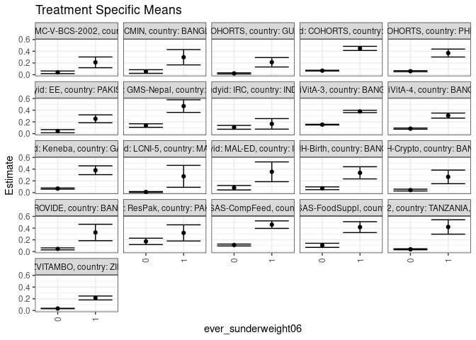

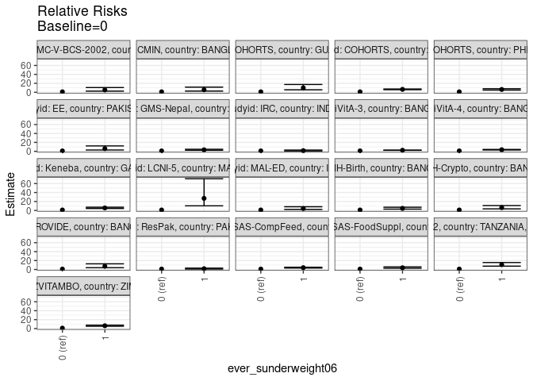

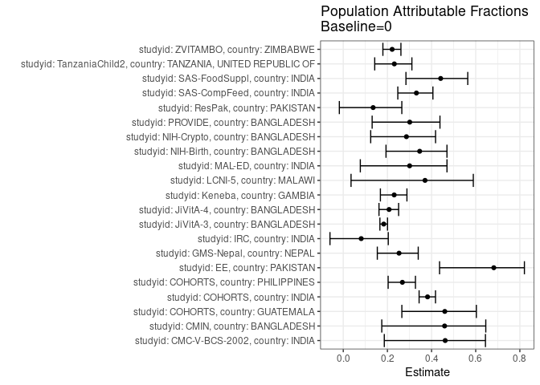

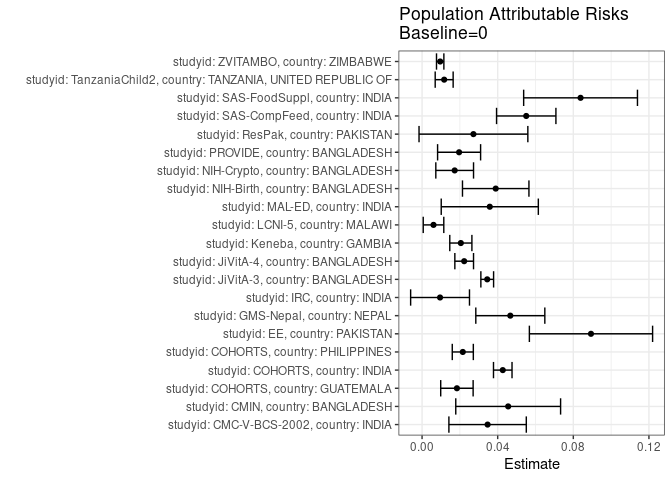

## Results Table

### Parameter: TSM

| studyid | country | intervention_level | baseline_level | estimate | ci_lower | ci_upper |
| --- | --- | --- | --- | --- | --- | --- |
| CMC-V-BCS-2002 | INDIA | 0 | NA | 0.0404040 | 0.0179802 | 0.0628279 |
| CMC-V-BCS-2002 | INDIA | 1 | NA | 0.2105263 | 0.1187467 | 0.3023059 |
| CMIN | BANGLADESH | 0 | NA | 0.0536585 | 0.0227500 | 0.0845670 |
| CMIN | BANGLADESH | 1 | NA | 0.2978723 | 0.1668680 | 0.4288767 |
| COHORTS | GUATEMALA | 0 | NA | 0.0216450 | 0.0122575 | 0.0310326 |
| COHORTS | GUATEMALA | 1 | NA | 0.2121212 | 0.1315528 | 0.2926896 |
| COHORTS | INDIA | 0 | NA | 0.0691064 | 0.0627519 | 0.0754608 |
| COHORTS | INDIA | 1 | NA | 0.4484536 | 0.4134592 | 0.4834480 |
| COHORTS | PHILIPPINES | 0 | NA | 0.0589135 | 0.0498855 | 0.0679416 |
| COHORTS | PHILIPPINES | 1 | NA | 0.3692308 | 0.3014834 | 0.4369781 |
| EE | PAKISTAN | 0 | NA | 0.0416667 | 0.0149824 | 0.0683509 |
| EE | PAKISTAN | 1 | NA | 0.2531646 | 0.1852731 | 0.3210560 |
| GMS-Nepal | NEPAL | 0 | NA | 0.1380671 | 0.1080136 | 0.1681205 |
| GMS-Nepal | NEPAL | 1 | NA | 0.4698795 | 0.3624168 | 0.5773423 |
| IRC | INDIA | 0 | NA | 0.1075581 | 0.0747780 | 0.1403383 |
| IRC | INDIA | 1 | NA | 0.1666667 | 0.0766464 | 0.2566869 |
| JiVitA-3 | BANGLADESH | 0 | NA | 0.1534467 | 0.1469673 | 0.1599261 |
| JiVitA-3 | BANGLADESH | 1 | NA | 0.3792188 | 0.3589191 | 0.3995186 |
| JiVitA-4 | BANGLADESH | 0 | NA | 0.0850749 | 0.0751510 | 0.0949989 |
| JiVitA-4 | BANGLADESH | 1 | NA | 0.3079848 | 0.2650750 | 0.3508946 |
| Keneba | GAMBIA | 0 | NA | 0.0683911 | 0.0580303 | 0.0787518 |
| Keneba | GAMBIA | 1 | NA | 0.3812500 | 0.3059769 | 0.4565231 |
| LCNI-5 | MALAWI | 0 | NA | 0.0102828 | 0.0031722 | 0.0173933 |
| LCNI-5 | MALAWI | 1 | NA | 0.2777778 | 0.0904991 | 0.4650565 |
| MAL-ED | INDIA | 0 | NA | 0.0833333 | 0.0453254 | 0.1213413 |
| MAL-ED | INDIA | 1 | NA | 0.3548387 | 0.1860502 | 0.5236272 |
| NIH-Birth | BANGLADESH | 0 | NA | 0.0735931 | 0.0497618 | 0.0974244 |
| NIH-Birth | BANGLADESH | 1 | NA | 0.3375000 | 0.2337868 | 0.4412132 |
| NIH-Crypto | BANGLADESH | 0 | NA | 0.0430267 | 0.0276970 | 0.0583564 |
| NIH-Crypto | BANGLADESH | 1 | NA | 0.2678571 | 0.1517921 | 0.3839221 |
| PROVIDE | BANGLADESH | 0 | NA | 0.0454545 | 0.0283705 | 0.0625386 |
| PROVIDE | BANGLADESH | 1 | NA | 0.3255814 | 0.1854092 | 0.4657536 |
| ResPak | PAKISTAN | 0 | NA | 0.1736842 | 0.1197015 | 0.2276669 |
| ResPak | PAKISTAN | 1 | NA | 0.3181818 | 0.1802629 | 0.4561007 |
| SAS-CompFeed | INDIA | 0 | NA | 0.1112062 | 0.0952555 | 0.1271569 |
| SAS-CompFeed | INDIA | 1 | NA | 0.4590909 | 0.3949503 | 0.5232315 |
| SAS-FoodSuppl | INDIA | 0 | NA | 0.1061644 | 0.0707876 | 0.1415412 |
| SAS-FoodSuppl | INDIA | 1 | NA | 0.4166667 | 0.3235703 | 0.5097630 |
| TanzaniaChild2 | TANZANIA, UNITED REPUBLIC OF | 0 | NA | 0.0388548 | 0.0302886 | 0.0474210 |
| TanzaniaChild2 | TANZANIA, UNITED REPUBLIC OF | 1 | NA | 0.4193548 | 0.2964961 | 0.5422136 |
| ZVITAMBO | ZIMBABWE | 0 | NA | 0.0336947 | 0.0301995 | 0.0371899 |
| ZVITAMBO | ZIMBABWE | 1 | NA | 0.2139130 | 0.1803943 | 0.2474318 |

### Parameter: E(Y)

| studyid | country | intervention_level | baseline_level | estimate | ci_lower | ci_upper |
| --- | --- | --- | --- | --- | --- | --- |
| CMC-V-BCS-2002 | INDIA | NA | NA | 0.0750670 | 0.0482904 | 0.1018437 |
| CMIN | BANGLADESH | NA | NA | 0.0992063 | 0.0622241 | 0.1361886 |
| COHORTS | GUATEMALA | NA | NA | 0.0400782 | 0.0280529 | 0.0521035 |
| COHORTS | INDIA | NA | NA | 0.1117877 | 0.1043506 | 0.1192249 |
| COHORTS | PHILIPPINES | NA | NA | 0.0804557 | 0.0703953 | 0.0905161 |
| EE | PAKISTAN | NA | NA | 0.1310160 | 0.0967738 | 0.1652583 |
| GMS-Nepal | NEPAL | NA | NA | 0.1847458 | 0.1534039 | 0.2160876 |
| IRC | INDIA | NA | NA | 0.1170732 | 0.0859146 | 0.1482317 |
| JiVitA-3 | BANGLADESH | NA | NA | 0.1879125 | 0.1813641 | 0.1944608 |
| JiVitA-4 | BANGLADESH | NA | NA | 0.1073532 | 0.0971813 | 0.1175251 |
| Keneba | GAMBIA | NA | NA | 0.0888980 | 0.0776057 | 0.1001903 |
| LCNI-5 | MALAWI | NA | NA | 0.0163317 | 0.0075211 | 0.0251422 |
| MAL-ED | INDIA | NA | NA | 0.1191489 | 0.0776405 | 0.1606574 |
| NIH-Birth | BANGLADESH | NA | NA | 0.1125461 | 0.0859151 | 0.1391771 |
| NIH-Crypto | BANGLADESH | NA | NA | 0.0602740 | 0.0429977 | 0.0775502 |
| PROVIDE | BANGLADESH | NA | NA | 0.0650407 | 0.0455353 | 0.0845460 |
| ResPak | PAKISTAN | NA | NA | 0.2008547 | 0.1494120 | 0.2522974 |
| SAS-CompFeed | INDIA | NA | NA | 0.1663067 | 0.1478935 | 0.1847199 |
| SAS-FoodSuppl | INDIA | NA | NA | 0.1900000 | 0.1515071 | 0.2284929 |
| TanzaniaChild2 | TANZANIA, UNITED REPUBLIC OF | NA | NA | 0.0505451 | 0.0409848 | 0.0601054 |
| ZVITAMBO | ZIMBABWE | NA | NA | 0.0432772 | 0.0394419 | 0.0471125 |

### Parameter: RR

| studyid | country | intervention_level | baseline_level | estimate | ci_lower | ci_upper |
| --- | --- | --- | --- | --- | --- | --- |
| CMC-V-BCS-2002 | INDIA | 0 | 0 | 1.000000 | 1.0000000 | 1.000000 |
| CMC-V-BCS-2002 | INDIA | 1 | 0 | 5.210526 | 2.5726624 | 10.553108 |
| CMIN | BANGLADESH | 0 | 0 | 1.000000 | 1.0000000 | 1.000000 |
| CMIN | BANGLADESH | 1 | 0 | 5.551257 | 2.6893509 | 11.458697 |
| COHORTS | GUATEMALA | 0 | 0 | 1.000000 | 1.0000000 | 1.000000 |
| COHORTS | GUATEMALA | 1 | 0 | 9.800000 | 5.5061841 | 17.442207 |
| COHORTS | INDIA | 0 | 0 | 1.000000 | 1.0000000 | 1.000000 |
| COHORTS | INDIA | 1 | 0 | 6.489325 | 5.7520636 | 7.321084 |
| COHORTS | PHILIPPINES | 0 | 0 | 1.000000 | 1.0000000 | 1.000000 |
| COHORTS | PHILIPPINES | 1 | 0 | 6.267333 | 4.9347008 | 7.959846 |
| EE | PAKISTAN | 0 | 0 | 1.000000 | 1.0000000 | 1.000000 |
| EE | PAKISTAN | 1 | 0 | 6.075949 | 3.0344655 | 12.165952 |
| GMS-Nepal | NEPAL | 0 | 0 | 1.000000 | 1.0000000 | 1.000000 |
| GMS-Nepal | NEPAL | 1 | 0 | 3.403270 | 2.4818525 | 4.666775 |
| IRC | INDIA | 0 | 0 | 1.000000 | 1.0000000 | 1.000000 |
| IRC | INDIA | 1 | 0 | 1.549549 | 0.8334278 | 2.880998 |
| JiVitA-3 | BANGLADESH | 0 | 0 | 1.000000 | 1.0000000 | 1.000000 |
| JiVitA-3 | BANGLADESH | 1 | 0 | 2.471338 | 2.3093933 | 2.644639 |
| JiVitA-4 | BANGLADESH | 0 | 0 | 1.000000 | 1.0000000 | 1.000000 |
| JiVitA-4 | BANGLADESH | 1 | 0 | 3.620159 | 3.0146631 | 4.347268 |
| Keneba | GAMBIA | 0 | 0 | 1.000000 | 1.0000000 | 1.000000 |
| Keneba | GAMBIA | 1 | 0 | 5.574559 | 4.3464205 | 7.149725 |
| LCNI-5 | MALAWI | 0 | 0 | 1.000000 | 1.0000000 | 1.000000 |
| LCNI-5 | MALAWI | 1 | 0 | 27.013889 | 10.2838431 | 70.960845 |
| MAL-ED | INDIA | 0 | 0 | 1.000000 | 1.0000000 | 1.000000 |
| MAL-ED | INDIA | 1 | 0 | 4.258064 | 2.2029714 | 8.230299 |
| NIH-Birth | BANGLADESH | 0 | 0 | 1.000000 | 1.0000000 | 1.000000 |
| NIH-Birth | BANGLADESH | 1 | 0 | 4.586029 | 2.9346552 | 7.166657 |
| NIH-Crypto | BANGLADESH | 0 | 0 | 1.000000 | 1.0000000 | 1.000000 |
| NIH-Crypto | BANGLADESH | 1 | 0 | 6.225370 | 3.5525141 | 10.909239 |
| PROVIDE | BANGLADESH | 0 | 0 | 1.000000 | 1.0000000 | 1.000000 |
| PROVIDE | BANGLADESH | 1 | 0 | 7.162791 | 4.0446508 | 12.684796 |
| ResPak | PAKISTAN | 0 | 0 | 1.000000 | 1.0000000 | 1.000000 |
| ResPak | PAKISTAN | 1 | 0 | 1.831956 | 1.0746647 | 3.122893 |
| SAS-CompFeed | INDIA | 0 | 0 | 1.000000 | 1.0000000 | 1.000000 |
| SAS-CompFeed | INDIA | 1 | 0 | 4.128287 | 3.3127771 | 5.144551 |
| SAS-FoodSuppl | INDIA | 0 | 0 | 1.000000 | 1.0000000 | 1.000000 |
| SAS-FoodSuppl | INDIA | 1 | 0 | 3.924731 | 2.6276709 | 5.862041 |
| TanzaniaChild2 | TANZANIA, UNITED REPUBLIC OF | 0 | 0 | 1.000000 | 1.0000000 | 1.000000 |
| TanzaniaChild2 | TANZANIA, UNITED REPUBLIC OF | 1 | 0 | 10.792869 | 7.4799667 | 15.573068 |
| ZVITAMBO | ZIMBABWE | 0 | 0 | 1.000000 | 1.0000000 | 1.000000 |
| ZVITAMBO | ZIMBABWE | 1 | 0 | 6.348567 | 5.2609454 | 7.661038 |

### Parameter: PAR

| studyid | country | intervention_level | baseline_level | estimate | ci_lower | ci_upper |
| --- | --- | --- | --- | --- | --- | --- |
| CMC-V-BCS-2002 | INDIA | 0 | NA | 0.0346630 | 0.0141918 | 0.0551341 |
| CMIN | BANGLADESH | 0 | NA | 0.0455478 | 0.0178222 | 0.0732734 |
| COHORTS | GUATEMALA | 0 | NA | 0.0184332 | 0.0098578 | 0.0270086 |
| COHORTS | INDIA | 0 | NA | 0.0426814 | 0.0377805 | 0.0475822 |
| COHORTS | PHILIPPINES | 0 | NA | 0.0215421 | 0.0159725 | 0.0271118 |
| EE | PAKISTAN | 0 | NA | 0.0893494 | 0.0567594 | 0.1219393 |
| GMS-Nepal | NEPAL | 0 | NA | 0.0466787 | 0.0284243 | 0.0649331 |
| IRC | INDIA | 0 | NA | 0.0095150 | -0.0060499 | 0.0250800 |
| JiVitA-3 | BANGLADESH | 0 | NA | 0.0344657 | 0.0310997 | 0.0378318 |
| JiVitA-4 | BANGLADESH | 0 | NA | 0.0222783 | 0.0173366 | 0.0272199 |
| Keneba | GAMBIA | 0 | NA | 0.0205069 | 0.0146551 | 0.0263587 |
| LCNI-5 | MALAWI | 0 | NA | 0.0060489 | 0.0006088 | 0.0114889 |
| MAL-ED | INDIA | 0 | NA | 0.0358156 | 0.0101353 | 0.0614959 |
| NIH-Birth | BANGLADESH | 0 | NA | 0.0389531 | 0.0213765 | 0.0565296 |
| NIH-Crypto | BANGLADESH | 0 | NA | 0.0172473 | 0.0072711 | 0.0272234 |
| PROVIDE | BANGLADESH | 0 | NA | 0.0195861 | 0.0082104 | 0.0309618 |
| ResPak | PAKISTAN | 0 | NA | 0.0271705 | -0.0016069 | 0.0559479 |
| SAS-CompFeed | INDIA | 0 | NA | 0.0551005 | 0.0394035 | 0.0707976 |
| SAS-FoodSuppl | INDIA | 0 | NA | 0.0838356 | 0.0537357 | 0.1139356 |
| TanzaniaChild2 | TANZANIA, UNITED REPUBLIC OF | 0 | NA | 0.0116903 | 0.0069439 | 0.0164367 |
| ZVITAMBO | ZIMBABWE | 0 | NA | 0.0095825 | 0.0076353 | 0.0115298 |

### Parameter: PAF

| studyid | country | intervention_level | baseline_level | estimate | ci_lower | ci_upper |
| --- | --- | --- | --- | --- | --- | --- |
| CMC-V-BCS-2002 | INDIA | 0 | NA | 0.4617605 | 0.1858748 | 0.6441557 |
| CMIN | BANGLADESH | 0 | NA | 0.4591220 | 0.1744745 | 0.6456208 |
| COHORTS | GUATEMALA | 0 | NA | 0.4599303 | 0.2654240 | 0.6029338 |
| COHORTS | INDIA | 0 | NA | 0.3818074 | 0.3435606 | 0.4178257 |
| COHORTS | PHILIPPINES | 0 | NA | 0.2677516 | 0.2033058 | 0.3269843 |
| EE | PAKISTAN | 0 | NA | 0.6819728 | 0.4362210 | 0.8206012 |
| GMS-Nepal | NEPAL | 0 | NA | 0.2526645 | 0.1542464 | 0.3396300 |
| IRC | INDIA | 0 | NA | 0.0812742 | -0.0602327 | 0.2038945 |
| JiVitA-3 | BANGLADESH | 0 | NA | 0.1834137 | 0.1659612 | 0.2005010 |
| JiVitA-4 | BANGLADESH | 0 | NA | 0.2075232 | 0.1617993 | 0.2507527 |
| Keneba | GAMBIA | 0 | NA | 0.2306794 | 0.1682476 | 0.2884250 |
| LCNI-5 | MALAWI | 0 | NA | 0.3703777 | 0.0352375 | 0.5890965 |
| MAL-ED | INDIA | 0 | NA | 0.3005952 | 0.0772697 | 0.4698700 |
| NIH-Birth | BANGLADESH | 0 | NA | 0.3461074 | 0.1935818 | 0.4697844 |
| NIH-Crypto | BANGLADESH | 0 | NA | 0.2861478 | 0.1242814 | 0.4180951 |
| PROVIDE | BANGLADESH | 0 | NA | 0.3011364 | 0.1308349 | 0.4380695 |
| ResPak | PAKISTAN | 0 | NA | 0.1352744 | -0.0177387 | 0.2652825 |
| SAS-CompFeed | INDIA | 0 | NA | 0.3313188 | 0.2471209 | 0.4061005 |
| SAS-FoodSuppl | INDIA | 0 | NA | 0.4412401 | 0.2839785 | 0.5639619 |
| TanzaniaChild2 | TANZANIA, UNITED REPUBLIC OF | 0 | NA | 0.2312843 | 0.1424894 | 0.3108846 |
| ZVITAMBO | ZIMBABWE | 0 | NA | 0.2214221 | 0.1795082 | 0.2611949 |